# DataScienceProject2

2022-12-03

```r
# Install new packages (only needed once!)
install.packages("caret")
install.packages("rpart")
install.packages("rpart.plot")
install.packages("randomForest")
```

### Arham Salman, Kevin Dang, Malik Hamed

## Title & Introduction

**Analysis of soccer Team Statistics across Major European Soccer Leagues**

**Our group decided to compare different European soccer leagues and tournaments to determine which team is the best in the world. We wanted to use Soccer statistics for our project because we enjoy the sport and want to figure out which team is the best in the world. We chose datasets from Kaggle as they had relevant data from teams in the seasons from 2013-2018. These sources were interesting because they were all similarly formatted, and show the proper statistics that measure a team’s success. Each unique row in the datasets represent the team name (categorical variable), matches played (numeric variable), goals scored (numeric), wins & losses (numeric), and rank finished (numeric). The sources used for this project are cited below: https://www.kaggle.com/datasets/jehanbhathena/big-5-european-football-leagues-stats https://www.kaggle.com/datasets/suwadith/europes-top-5-league-tables-2009-2018 https://www.kaggle.com/datasets/quadeer15sh/premier-league-standings-11-seasons-20102021**

```r
#The following chunk of code renames each dataset exported from Kaggle to make data easier to analyze and save the import. (Arham)
Bundesliga <- read.csv("~/Bundesliga Points Table (2013-2018).csv", header = TRUE)
EPL <- read.csv("~/EPL Standings 2000-2022.csv", header = TRUE)
LaLiga <- read.csv("~/Big 5 European football leagues teams stats.csv", header = TRUE)
```

We mutated and filtered the datasets so that they all have the same name for certain variables we will join them by later.

```r
#changes variable names to a standard for joining later for all three leagues. (Arham)
LaLiga <- LaLiga %>%
  filter(League == "La Liga") %>%
  mutate(Year = season, Team = squad, Rank = rank, Games = games, Wins = wins, Draws = draws, Losses = losses, Points = points, GoalsFor = goals_for, GoalsAgainst = goals_against)


Bundesliga <- Bundesliga %>%
  mutate(Games = Played, Wins = Win, Draws = Draw, Losses = Loss, GoalsFor = Goals.For, GoalsAgainst = Goals.Against) %>%
  drop_na(Rank)

EPL <- EPL %>%
  mutate(Year = Season, Rank = Pos, Games = Pld, Wins = W, Draws = D, Losses = L, Points = Pts,GoalsFor = GF, GoalsAgainst = GA)
```

**For the LaLiga dataset, we filtered out the league “LaLiga” from the Big 5 European football league teams stats dataset to only include one league for future analyses.**

Then, we used full join to combine the three datasets into one big dataset that contains all the important observations from the other datasets under key variables

```r
#first join function to join the leagues La Liga and Premier League. (Malik)


Join2 <- LaLiga %>%
  full_join(EPL, by = c("Rank", "Team", "Games", "Wins", "Year", "Draws", "Losses", "Points","GoalsFor", "GoalsAgainst", "League"))

#second join function which joins the previous dataset to the Bundesliga league (Malik)

BigDataset <- Join2 %>%
  full_join(Bundesliga, by = c("Team", "Rank", "Games", "Wins", "Year", "Draws", "Losses", "Points", "GoalsFor","GoalsAgainst", "League"))

BigDatasetFinal <- BigDataset %>%
  select(Team, Rank, Wins, Losses, GoalsFor, GoalsAgainst, Year, Games, Points, Draws, League) %>%
  filter(Year > 2013 & Year < 2018) %>%
  arrange(Year, League) %>%
  group_by(Team, Wins)
```

## Exploratory Data Analysis

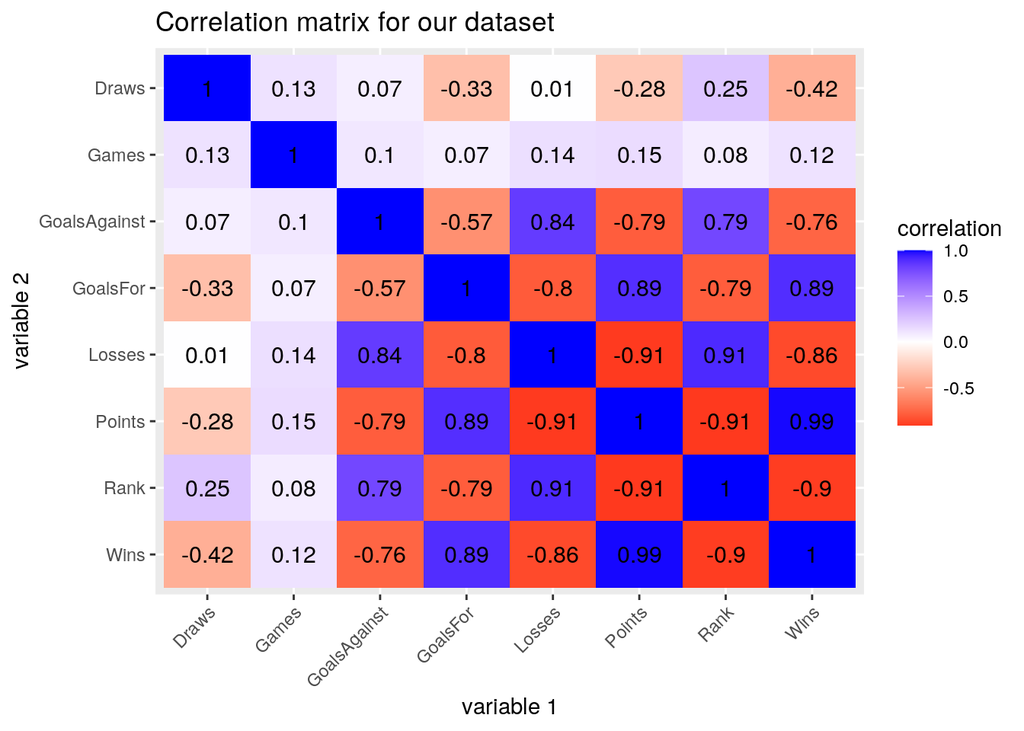

```r
BigDatasetFinalnum <- BigDatasetFinal %>%
  ungroup() %>%
  select(-Team, -Year, -League)


# Find the correlations among all variables
cor(BigDatasetFinalnum, use = "pairwise.complete.obs") %>%
  # Save as a data frame
  as.data.frame %>%
  # Convert row names to an explicit variable
  rownames_to_column %>%
  # Pivot so that all correlations appear in the same column
  pivot_longer(-1,
               names_to = "other_var",
               values_to = "correlation") %>%
  # Define ggplot (reorder values on y-axis)
  ggplot(aes(x = rowname,
             y = ordered(other_var, levels = rev(sort(unique(other_var)))),
             fill = correlation)) +
  # Heat map with geom_tile
  geom_tile() +
  # Change the scale to make the middle appear neutral
  scale_fill_gradient2(low = "red", mid = "white", high = "blue") +
  # Overlay values
  geom_text(aes(label = round(correlation,2)), color = "black", size = 4) +
  # Angle the x-axis label to 45 degrees
  theme(axis.text.x = element_text(angle = 45, hjust = 1)) +
  # Give title and labels
  labs(title = "Correlation matrix for our dataset",
       x = "variable 1", y = "variable 2")
```

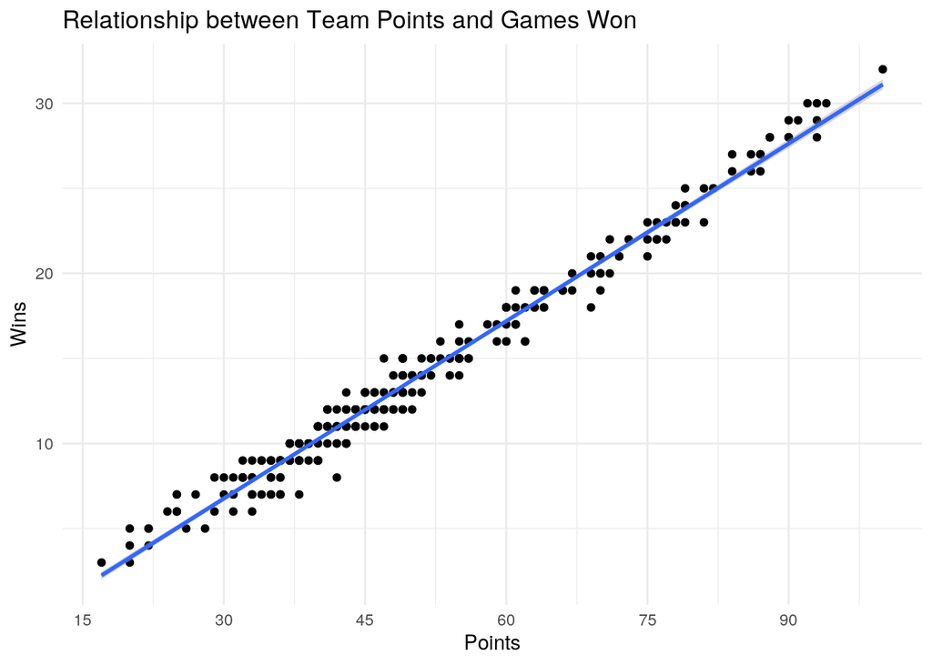

```r
# Correlation between Team Points and Games Won (0.99)
ggplot(data = BigDatasetFinalnum, aes(x = Points, y = Wins)) + geom_point() + geom_smooth(method = "lm") + theme_minimal() + labs(title = "Relationship between Team Points and Games Won", x = "Points") + scale_x_continuous(breaks = seq(0, 120, 15))
```

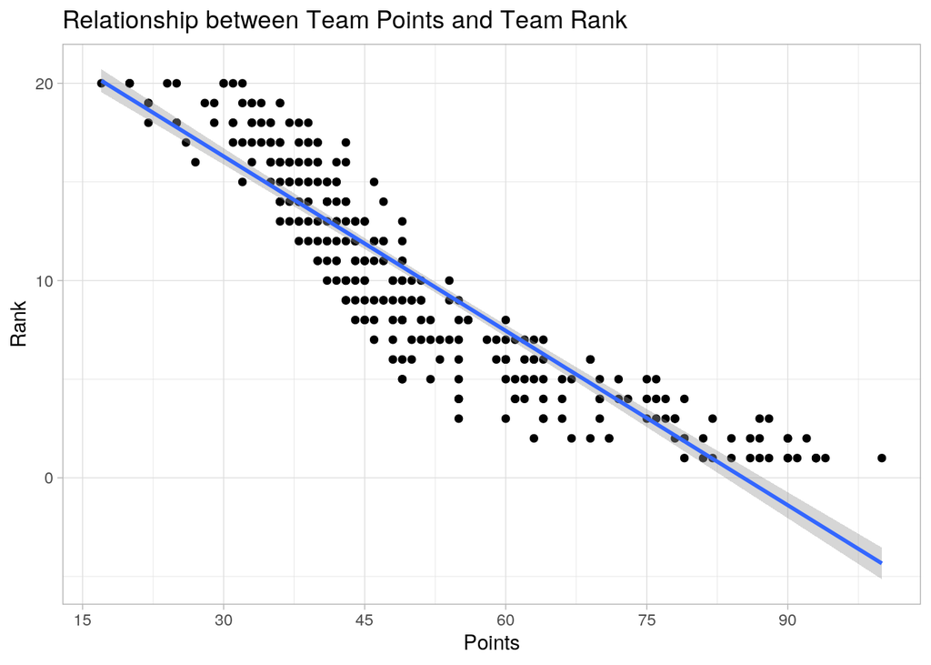

```r
# Correlation between Team Points and Rank (-0.91)
ggplot(data = BigDatasetFinalnum, aes(x = Points, y = Rank)) + geom_point() + geom_smooth(method = "lm") + theme_light() + labs(title = "Relationship between Team Points and Team Rank", x = "Points") + scale_x_continuous(breaks = seq(0, 120, 15))
```

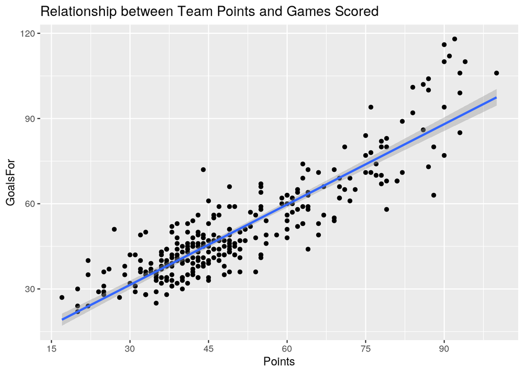

```r
# Correlation between Goals Scored and Team Points (0.89)
ggplot(data = BigDatasetFinalnum, aes(x = Points, y = GoalsFor)) + geom_point() + geom_smooth(method = "lm") + theme_gray() + labs(title = "Relationship between Team Points and Games Scored", x = "Points") + scale_x_continuous(breaks = seq(0, 120, 15))
```